# modelado_data

Alejandro D., Aythami L., Tomás S.

2026-02-06

En este documento documentaremos el proceso ETL (Extracción, Transformación y Carga) de los datasets públicos del Cabildo.

# Movilidad (Guaguas y tranvía)

Vamos a unificar ambos datasets con la información de las paradas, y limpiar las columnas irrelevantes.

```r
# 1. Cargar datos brutos
raw_guaguas <- st_read("data-raw/paradas-de-guagua.geojson", quiet = TRUE)
raw_tranvia <- st_read("data-raw/paradas-de-tranvia.geojson", quiet = TRUE)

# 2. Limpieza Guaguas
clean_guaguas <- raw_guaguas %>%
  clean_names() %>%  # Pone todo en minúsculas y quita espacios
  select(nombre = parada_nombre, geometry) %>% # Nos quedamos solo con el nombre y la pos
  mutate(tipo = "Guagua")

# 3. Limpieza Tranvía
clean_tranvia <- raw_tranvia %>%
  clean_names() %>%
  select(nombre = parada_nombre, geometry) %>%
  mutate(tipo = "Tranvia")
```

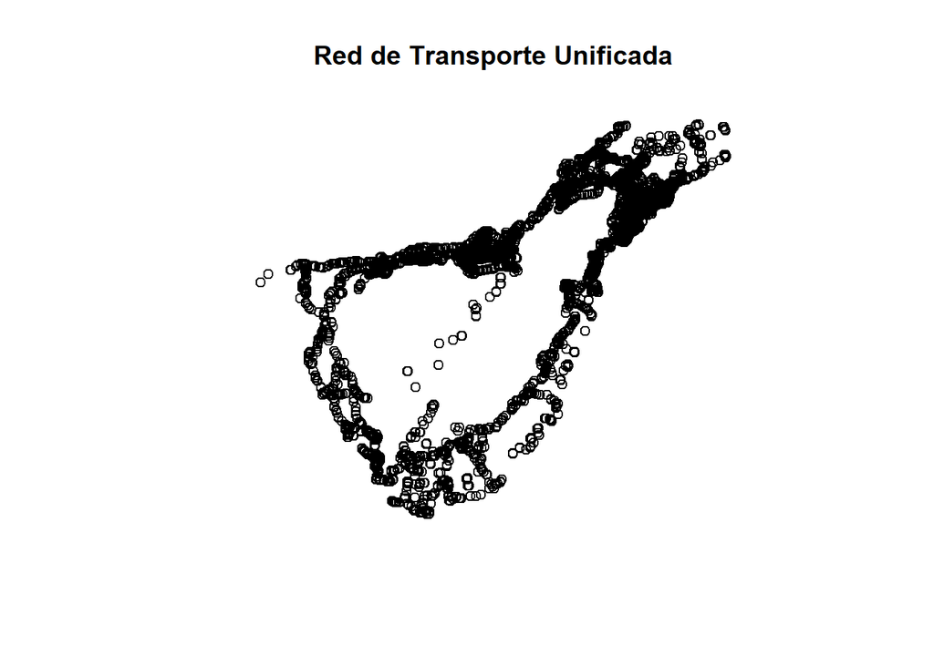

```r
# 4. Unificación
movilidad_unificada <- bind_rows(clean_guaguas, clean_tranvia)

# 5. Verificación de Coordenadas (CRÍTICO)
# Aseguramos que sea WGS84 (EPSG:4326) para la web
movilidad_unificada <- st_transform(movilidad_unificada, crs = 4326)

# Visualización rápida
plot(st_geometry(movilidad_unificada), main = "Red de Transporte Unificada")
```

# Salud

Dividiremos los distintos sectores en grupos, para poder otorgar pesos distintos a centros más importantes que otro a la hora de buscar un lugar en el que vivir.  
Los distintos sevicios que se recogen en el dataset de salud son:

```
##  [1] "servicios profesionales medicos"    "fisioterapia rehabilitacion"
##  [3] "servicios asistenciales"            "centro de salud"
##  [5] "clinica dental"                     "terapias alternativas"
##  [7] "servicios profesionales psicologia" "servicios profesionales limpieza"
##  [9] "farmacia cooperativa"               "farmacia"
## [11] "banca servicios financieros"        "servicios profesionales logopedia"
## [13] "servicios hospitalarios"            "centro reconocimiento conductores"
## [15] "servicios veterinarios"             "servicios profesionales podologia"
## [17] "laboratorio analisis clinicos"
```

#### Exclusión

Se han eliminado registros que, aunque presentes en el dataset original, introducen ruido o no aportan valor a la decisión de residencia. Se descartan categorías erróneas como “banca servicios financieros” y “servicios profesionales limpieza” (inconsistencias del proveedor de datos). Asimismo, se excluyen “farmacia cooperativa” (almacenes logísticos sin venta al público), “centro reconocimiento conductores” (baja frecuencia de uso) y “terapias alternativas” (por subjetividad en la percepción de valor sanitario).

#### Jerarquización y ponderación

Los servicios restantes se han agrupado en clústeres funcionales con pesos iniciales diferenciados:

- Grupo 1 - Infraestructura Vital (Peso 10): Incluye Hospitales y Centros de Salud. Son activos críticos que garantizan la seguridad y la atención de urgencias, elevando significativamente el valor de la zona.
- Grupo 2 - Necesidad Recurrente (Peso 8): Incluye exclusivamente Farmacias. Su alta frecuencia de uso y necesidad inmediata las convierte en un servicio esencial de proximidad (“barrio de 15 minutos”).
- Grupo 3 - Asistencia Intermedia (Peso 6): Categoría asignada a “Servicios Asistenciales”. Representa un nivel de cobertura importante (mutuas, soporte), pero sin la criticidad de un hospital ni la inmediatez de una farmacia.
- Grupo 4 - Especialistas y Bienestar (Peso 4): Incluye fisioterapia, odontología, psicología, etc. Son servicios de valor añadido que funcionan bajo cita previa; su cercanía es positiva pero no determinante para la elección de vivienda.
- Grupo 5 - Servicios Veterinarios (Peso Dinámico): Se segrega esta categoría para permitir una personalización dinámica en la aplicación (activable solo para usuarios con mascotas).

```r
clean_salud <- raw_salud %>%
  # Limpiamos nombres de columnas por si acaso (quita acentos, espacios -> guiones bajos)
  janitor::clean_names() %>%

  # SELECCIÓN: Nos quedamos solo con lo útil y renombramos para que sea más claro
  select(
    nombre,
    actividad_tipo,
    municipio = municipio_nombre,
    calle = direccion_nombre_via,
    numero = direccion_numero,
    telefono,   # Mantenemos esto para la funcionalidad de 'Llamada rápida'
    geometry    # Nunca quites esto, es la ubicación
  ) %>%

  # --- 2. FILTRADO (Excluir lo inútil) ---
  filter(
    !actividad_tipo %in% c(
      "banca servicios financieros",
      "servicios profesionales limpieza",
      "terapias alternativas",
      "centro reconocimiento conductores",
      "farmacia cooperativa"
    )
  ) %>%

  # --- 3. CREACIÓN DE GRUPOS Y PESOS (Feature Engineering) ---
  mutate(
    # Unificamos dirección para que quede bonito en la App: "Calle Castillo, 23"
    direccion_completa = paste(calle, numero, sep = ", "),

    # Creamos la categoría simplificada
    grupo_salud = case_when(
      actividad_tipo %in% c("servicios hospitalarios", "centro de salud") ~ "Vital",
      actividad_tipo == "farmacia" ~ "Farmacia",
      actividad_tipo == "servicios asistenciales" ~ "Asistencial",
      actividad_tipo == "servicios veterinarios" ~ "Veterinario",
      # Todo lo demás va al grupo especialistas (dentistas, fisios, etc.)
      TRUE ~ "Especialista"
    ),

    # Asignamos el peso numérico para el algoritmo
    peso_inicial = case_when(
      grupo_salud == "Vital" ~ 10,
      grupo_salud == "Farmacia" ~ 8,
      grupo_salud == "Asistencial" ~ 6,
      grupo_salud == "Especialista" ~ 4,
      grupo_salud == "Veterinario" ~ NA, # Peso 0 por defecto (se activa si usuario tiene mascota)
      TRUE ~ 1
    )
  )

# --- 4. CHEQUEO FINAL ---
# Vemos cómo ha quedado la estructura
glimpse(clean_salud)
```

```
## Rows: 1,353
## Columns: 10
## $ nombre             <chr> "Acufade", "Adacea Tenerife", "Afur Centro de Fisio…
## $ actividad_tipo     <chr> "servicios profesionales medicos", "fisioterapia re…
## $ municipio          <chr> "Granadilla de Abona", "La Victoria", "La Victoria"…
## $ calle              <chr> "Mencey de Abona", "General TF 217 Norte", "General…
## $ numero             <chr> "41", "89", "80", "48", "1", "1", "33", "25", "7", …
## $ telefono           <dbl> 922770539, 617552191, 922313127, 651855097, 9225423…
## $ geometry           <POINT [°]> POINT (-16.57876 28.11656), POINT (-16.47011 …
## $ direccion_completa <chr> "Mencey de Abona, 41", "General TF 217 Norte, 89", …
## $ grupo_salud        <chr> "Especialista", "Especialista", "Especialista", "As…
## $ peso_inicial       <dbl> 4, 4, 4, 6, 6, 4, 4, 6, 10, 10, 4, 4, 4, 4, 4, 6, 6…
```

```r
# Comprobamos que los grupos tienen lógica
table(clean_salud$grupo_salud, clean_salud$peso_inicial)
```

```
##
##                  4   6   8  10
##   Asistencial    0 287   0   0
##   Especialista 464   0   0   0
##   Farmacia       0   0 325   0
##   Veterinario    0   0   0   0
##   Vital          0   0   0 158
```

```r
# Visualización rápida para comprobar
mapview(clean_salud, zcol = "grupo_salud", layer.name = "Salud por Categoría")
```

[interactive chart not shown]

# Centros educativos y culturales

Los distintos tipos de actividades que encontramos en este dataset son:

```
##  [1] "enseñanza especializada"
##  [2] "enseñanza idiomas"
##  [3] "enseñanza profesional"
##  [4] "biblioteca ludoteca"
##  [5] "museos salas de arte"
##  [6] "centro cultural"
##  [7] "enseñanza secundaria"
##  [8] "guarderias centros infantiles"
##  [9] "enseñanza a distancia"
## [10] "enseñanza especial"
## [11] "enseñanza infantil y primaria"
## [12] "enseñanza profesorado"
## [13] "café"
## [14] "asociacion cultural"
## [15] "enseñanza adultos"
## [16] "enseñanza obligatoria"
## [17] "enseñanza infantil"
## [18] "enseñanza universitaria"
## [19] "centro comercial hogar informatica telecomunicaciones"
## [20] "residencia educativa"
```

Siguiendo la metodología aplicada en el bloque sanitario, se ha procesado el dataset de Centros educativos y culturales para distinguir entre servicios de escolarización obligatoria, formación superior y oferta cultural. Esta distinción es fundamental para adaptar el algoritmo a diferentes perfiles demográficos (familias con niños vs. estudiantes universitarios).

#### Depuración de Datos:

Se han eliminado registros inconsistentes con la finalidad del dataset, tales como “café” (error de categorización), “centro comercial…” (duplicidad con el dataset de comercio) y “enseñanza a distancia” (cuya ubicación física es irrelevante para el cálculo de proximidad residencial).

#### Categorización Funcional:

Los activos restantes se han segmentado en tres niveles de prioridad base:

- Grupo 1 - Escolarización Básica (Peso 10): Incluye centros de enseñanza infantil, primaria y secundaria/obligatoria. Representa el factor de mayor peso para familias, dado que determina la logística diaria de transporte escolar.
- Grupo 2 - Formación Específica y Superior (Peso 6): Agrupa la enseñanza universitaria, profesional, idiomas, adultos y educación especial. Aunque vitales, su público objetivo es más segmentado o dispone de mayor autonomía de movilidad que el alumnado de educación básica.
- Grupo 3 - Cultura y Ocio (Peso 4): Bibliotecas, centros culturales y museos. Se consideran activos de valor añadido (“Barrio Culto”) que mejoran la calidad de vida general pero no constituyen una necesidad logística diaria estricta.

```r
# --- LIMPIEZA DE EDUCACIÓN Y CULTURA ---

# 1. DEFINICIÓN DE LISTAS (Taxonomía)

# Grupo 1: Colegios (Básica y Obligatoria) -> Peso 10
cat_colegios <- c("enseñanza infantil y primaria", "enseñanza secundaria",
                  "enseñanza obligatoria", "guarderias centros infantiles",
                  "enseñanza infantil")

# Grupo 2: Formación (Superior, Especializada y Adultos) -> Peso 6
# Nota: 'enseñanza especial' movida aquí por decisión de diseño.
cat_formacion <- c("enseñanza universitaria", "enseñanza profesional",
                   "enseñanza idiomas", "enseñanza adultos",
                   "enseñanza especializada", "enseñanza especial")

# Grupo 3: Cultura -> Peso 4
cat_cultura   <- c("biblioteca ludoteca", "centro cultural",
                   "museos salas de arte", "asociacion cultural")

# Blacklist (A eliminar)
cat_borrar_edu <- c("café", "centro comercial hogar informatica telecomunicaciones",
                    "enseñanza a distancia", "enseñanza profesorado",
                    "residencia educativa")

# 2. PROCESAMIENTO

clean_edu <- raw_edu %>%
  janitor::clean_names() %>% # Asegura que los nombres estén limpios (actividad_tipo, etc.)

  # Selección de columnas (Usando los nombres que me has confirmado)
  select(
    nombre,
    actividad_tipo,          # Esta contiene la categoría ("enseñanza...", "biblioteca...")
    municipio = municipio_nombre,
    calle = direccion_nombre_via,
    numero = direccion_numero,
    web,                     # Conservamos web por si acaso
    geometry
  ) %>%

  # Filtrado de basura
  filter(!actividad_tipo %in% cat_borrar_edu) %>%

  # Creación de Grupos y Pesos Base
  mutate(
    # Dirección legible para el popup del mapa
    direccion_completa = paste(calle, numero, sep = ", "),

    # Asignación de Grupo
    grupo_edu = case_when(
      actividad_tipo %in% cat_colegios  ~ "Colegio",
      actividad_tipo %in% cat_formacion ~ "Formacion",
      actividad_tipo %in% cat_cultura   ~ "Cultura",
      TRUE ~ "Otros"
    ),

    # Peso Inicial (Por defecto)
    peso_inicial = case_when(
      grupo_edu == "Colegio"   ~ 10,
      grupo_edu == "Formacion" ~ 6,
      grupo_edu == "Cultura"   ~ 4,
      TRUE ~ 1
    )
  )

# --- 3. VERIFICACIÓN Y MAPA ---

# Tabla resumen para ver cuántos hay de cada tipo
print("Resumen de Centros Educativos por Grupo:")
```

```
## [1] "Resumen de Centros Educativos por Grupo:"
```

```r
table(clean_edu$grupo_edu)
```

```
##
##   Colegio   Cultura Formacion
##       509       289       238
```

```r
# MAPA INTERACTIVO (Para visualización)
library(mapview)

# Definimos colores para cada grupo:
# Colegio (Rojo/Naranja), Formación (Azul), Cultura (Verde)
mapview(clean_edu,
        zcol = "grupo_edu",
        layer.name = "Educación y Cultura",
        col.regions = c("orange", "green", "blue"))
```

[interactive chart not shown]